member: Siyu Lin, Jingyuan Liang, Zhen Yan

## Import data

```python
import pandas as pd
import numpy as np
```

```python
ACAdata = pd.read_csv("/Users/jasondeng/Desktop/CollegeScorecard.csv")
ACAdata.shape
```

```
(7804, 1725)
```

## select variables

```python
ACAdata2 = ACAdata[['UNITID', 'PCIP13', 'CIP13BACHL', 'ADM_RATE_ALL', 'RET_FT4', 'RET_PT4', 'RET_FTL4', 'RET_PTL4', 'C150_4', 'C200_4', 'C200_L4', 'C150_4_POOLED','CDR3', 'PELL_RPY_3YR_RT', 'GRAD_DEBT_MDN', 'WDRAW_DEBT_MDN', 'INEXPFTE', 'AVGFACSAL']]
ACAdata2
```

|  | UNITID | PCIP13 | CIP13BACHL | ADM_RATE_ALL | RET_FT4 | RET_PT4 | RET_FTL4 | RET_PTL4 | C150_4 | C200_4 | C200_L4 | C150_4_POOLED | CDR3 | PELL_RPY_3YR_RT | GRAD_DEBT_MDN | WDRAW_DEBT_MDN | INEXPFTE | AVGFACSAL |
| --- | --- | --- | --- | --- | --- | --- | --- | --- | --- | --- | --- | --- | --- | --- | --- | --- | --- | --- |
| 0 | 100654 | 0.1490 | 2.0 | 0.8989 | 0.6314 | 0.5000 | NaN | NaN | 0.2914 | 0.3520 | NaN | 0.308718 | 0.163 | 0.443586698 | 33611.5 | 14250 | 7459.0 | 7079.0 |
| 1 | 100663 | 0.0862 | 2.0 | 0.8673 | 0.8016 | 0.5000 | NaN | NaN | 0.5377 | 0.4881 | NaN | 0.508550 | 0.080 | 0.732297853 | 23117 | 11886 | 17208.0 | 10170.0 |
| 2 | 100690 | 0.0000 | 0.0 | NaN | 0.3750 | 0.3333 | NaN | NaN | 0.6667 | 0.3333 | NaN | 0.285738 | 0.089 | PrivacySuppressed | 26995 | 9500 | 5123.0 | 3849.0 |
| 3 | 100706 | 0.0173 | 2.0 | 0.8062 | 0.8098 | 0.4444 | NaN | NaN | 0.4835 | 0.5048 | NaN | 0.478211 | 0.077 | 0.738341969 | 24738 | 10500 | 9352.0 | 9341.0 |
| 4 | 100724 | 0.2150 | 2.0 | 0.5125 | 0.6219 | 0.3023 | NaN | NaN | 0.2517 | 0.3013 | NaN | 0.257482 | 0.191 | 0.320016821 | 33452 | 12500 | 7393.0 | 6557.0 |
| ... | ... | ... | ... | ... | ... | ... | ... | ... | ... | ... | ... | ... | ... | ... | ... | ... | ... | ... |
| 7799 | 48285703 | NaN | NaN | NaN | NaN | NaN | NaN | NaN | NaN | NaN | NaN | NaN | 0.160 | 0.42789148 | 10500 | 5500 | NaN | NaN |
| 7800 | 48285704 | NaN | NaN | NaN | NaN | NaN | NaN | NaN | NaN | NaN | NaN | NaN | 0.160 | 0.42789148 | 10500 | 5500 | NaN | NaN |
| 7801 | 48285705 | NaN | NaN | NaN | NaN | NaN | NaN | NaN | NaN | NaN | NaN | NaN | 0.160 | 0.42789148 | 10500 | 5500 | NaN | NaN |
| 7802 | 48285706 | NaN | NaN | NaN | NaN | NaN | NaN | NaN | NaN | NaN | NaN | NaN | 0.160 | 0.42789148 | 10500 | 5500 | NaN | NaN |
| 7803 | 48285707 | NaN | NaN | NaN | NaN | NaN | NaN | NaN | NaN | NaN | NaN | NaN | 0.160 | 0.42789148 | 10500 | 5500 | NaN | NaN |

7804 rows × 18 columns

## coverting "privacysuppressed" to float

```python
ACAdata2['PCIP13'].replace('PrivacySuppressed',0.0)
ACAdata2['CIP13BACHL'].replace('PrivacySuppressed',0.0)
ACAdata2['ADM_RATE_ALL'].replace('PrivacySuppressed',0.0)
ACAdata2['RET_FT4'].replace('PrivacySuppressed',0.0)
ACAdata2['RET_PT4'].replace('PrivacySuppressed',0.0)
ACAdata2['RET_FTL4'].replace('PrivacySuppressed',0.0)
ACAdata2['RET_PTL4'].replace('PrivacySuppressed',0.0)
ACAdata2['C150_4'].replace('PrivacySuppressed',0.0)
ACAdata2['C200_4'].replace('PrivacySuppressed',0.0)
ACAdata2['C200_L4'].replace('PrivacySuppressed',0.0)
ACAdata2['C150_4_POOLED'].replace('PrivacySuppressed',0.0)
ACAdata2['CDR3'].replace('PrivacySuppressed',0.0)
ACAdata2['PELL_RPY_3YR_RT'].replace('PrivacySuppressed',0.0)
ACAdata2['GRAD_DEBT_MDN'].replace('PrivacySuppressed',0.0)
ACAdata2['INEXPFTE'].replace('PrivacySuppressed',0.0)
ACAdata2['WDRAW_DEBT_MDN'].replace('PrivacySuppressed',0.0)
ACAdata2['AVGFACSAL'].replace('PrivacySuppressed',0.0)
ACAdata2 = ACAdata2.replace('PrivacySuppressed', 0.0)
ACAdata2 = ACAdata2.replace('nan', -1)
ACAdata2 = ACAdata2.fillna(-1)
ACAdata2
```

|  | UNITID | PCIP13 | CIP13BACHL | ADM_RATE_ALL | RET_FT4 | RET_PT4 | RET_FTL4 | RET_PTL4 | C150_4 | C200_4 | C200_L4 | C150_4_POOLED | CDR3 | PELL_RPY_3YR_RT | GRAD_DEBT_MDN | WDRAW_DEBT_MDN | INEXPFTE | AVGFACSAL |
| --- | --- | --- | --- | --- | --- | --- | --- | --- | --- | --- | --- | --- | --- | --- | --- | --- | --- | --- |
| 0 | 100654 | 0.1490 | 2.0 | 0.8989 | 0.6314 | 0.5000 | -1.0 | -1.0 | 0.2914 | 0.3520 | -1.0 | 0.308718 | 0.163 | 0.443586698 | 33611.5 | 14250 | 7459.0 | 7079.0 |
| 1 | 100663 | 0.0862 | 2.0 | 0.8673 | 0.8016 | 0.5000 | -1.0 | -1.0 | 0.5377 | 0.4881 | -1.0 | 0.508550 | 0.080 | 0.732297853 | 23117 | 11886 | 17208.0 | 10170.0 |
| 2 | 100690 | 0.0000 | 0.0 | -1.0000 | 0.3750 | 0.3333 | -1.0 | -1.0 | 0.6667 | 0.3333 | -1.0 | 0.285738 | 0.089 | 0.0 | 26995 | 9500 | 5123.0 | 3849.0 |
| 3 | 100706 | 0.0173 | 2.0 | 0.8062 | 0.8098 | 0.4444 | -1.0 | -1.0 | 0.4835 | 0.5048 | -1.0 | 0.478211 | 0.077 | 0.738341969 | 24738 | 10500 | 9352.0 | 9341.0 |
| 4 | 100724 | 0.2150 | 2.0 | 0.5125 | 0.6219 | 0.3023 | -1.0 | -1.0 | 0.2517 | 0.3013 | -1.0 | 0.257482 | 0.191 | 0.320016821 | 33452 | 12500 | 7393.0 | 6557.0 |
| ... | ... | ... | ... | ... | ... | ... | ... | ... | ... | ... | ... | ... | ... | ... | ... | ... | ... | ... |
| 7799 | 48285703 | -1.0000 | -1.0 | -1.0000 | -1.0000 | -1.0000 | -1.0 | -1.0 | -1.0000 | -1.0000 | -1.0 | -1.000000 | 0.160 | 0.42789148 | 10500 | 5500 | -1.0 | -1.0 |
| 7800 | 48285704 | -1.0000 | -1.0 | -1.0000 | -1.0000 | -1.0000 | -1.0 | -1.0 | -1.0000 | -1.0000 | -1.0 | -1.000000 | 0.160 | 0.42789148 | 10500 | 5500 | -1.0 | -1.0 |
| 7801 | 48285705 | -1.0000 | -1.0 | -1.0000 | -1.0000 | -1.0000 | -1.0 | -1.0 | -1.0000 | -1.0000 | -1.0 | -1.000000 | 0.160 | 0.42789148 | 10500 | 5500 | -1.0 | -1.0 |
| 7802 | 48285706 | -1.0000 | -1.0 | -1.0000 | -1.0000 | -1.0000 | -1.0 | -1.0 | -1.0000 | -1.0000 | -1.0 | -1.000000 | 0.160 | 0.42789148 | 10500 | 5500 | -1.0 | -1.0 |
| 7803 | 48285707 | -1.0000 | -1.0 | -1.0000 | -1.0000 | -1.0000 | -1.0 | -1.0 | -1.0000 | -1.0000 | -1.0 | -1.000000 | 0.160 | 0.42789148 | 10500 | 5500 | -1.0 | -1.0 |

7804 rows × 18 columns

## PCA

```python
from sklearn.decomposition import PCA
ACAdata2_noid = ACAdata2.drop(['UNITID'], axis = 1)
pca = PCA(n_components=7)
pca.fit(ACAdata2_noid)
print("The principal components are:")
print(pca.components_)
print("The explained variances are:")
print(pca.explained_variance_)
```

```
The principal components are:
[[ 2.77641105e-06  2.50678393e-05  3.50901303e-05  3.96504824e-05
   2.27734208e-05 -3.89846410e-05 -2.11188504e-05  3.55880922e-05
   3.38941033e-05 -3.52052561e-05  3.56172227e-05  1.35622677e-06
   2.73302258e-05  9.30864981e-01  3.41951520e-01 -2.48607883e-02
   1.26259549e-01]
 [ 1.87663629e-07  1.41807996e-05  1.41493232e-05  1.78883947e-05
   5.67453041e-06 -1.87116583e-05 -8.14052585e-06  1.65060937e-05
   1.74757307e-05 -1.68524359e-05  1.68709781e-05 -2.77119671e-06
  -3.89603502e-06 -5.99528914e-03  3.67781275e-02  9.89529889e-01
   1.39434653e-01]
 [-1.42473650e-05 -7.68112983e-05 -5.92954519e-05 -7.39490922e-05
  -4.72501383e-05  4.33708591e-05 -8.00016492e-06 -6.96387105e-05
  -6.61206115e-05  4.47197770e-05 -6.98773602e-05  2.85766821e-06
  -2.08727610e-05  2.76936977e-01 -4.30854170e-01  1.37162717e-01
  -8.47854320e-01]
 [ 3.90751469e-06 -2.57311045e-05  4.84804781e-06 -3.10112176e-05
  -1.12321817e-05  4.62050528e-05  1.35842157e-05 -3.35614578e-05
  -2.52665524e-05  4.35603574e-05 -3.23444394e-05  1.62666443e-06
   4.11199131e-05 -2.38244304e-01  8.34314811e-01  3.74022562e-02
  -4.95741372e-01]
 [-4.10086078e-04 -2.30913579e-01 -2.61895050e-01 -3.76646592e-01
  -2.04485193e-01  4.04646899e-01  2.99738475e-01 -3.32806750e-01
  -3.01924200e-01  3.50060426e-01 -3.34140158e-01  2.31438338e-02
   6.46871782e-02  6.89028497e-05  3.39838549e-05  1.82935137e-05
   2.04924641e-04]
 [-2.64523776e-01 -4.05438164e-01 -1.74897244e-01 -2.30627100e-01
  -1.64965518e-01 -4.56725125e-01 -3.33433371e-01 -1.82810130e-01
  -2.30581976e-01 -4.50547492e-01 -1.77995714e-01 -1.95008089e-03
  -1.16674631e-01 -1.23313232e-05  4.95674326e-05 -6.12388874e-06
   5.90604933e-05]
 [ 5.31796014e-02  2.13687831e-01 -9.08460260e-01  1.22098136e-01
   2.08972161e-01 -7.78572012e-02  1.61968825e-01  8.27396296e-02
   4.07377331e-02 -1.26274642e-01  8.85683404e-02  1.08646244e-02
  -5.40680008e-02  3.66319091e-07  2.60821665e-05  2.26070530e-06
  -1.98585190e-05]]
The explained variances are:
[1.18936080e+08 7.77996530e+07 9.92320718e+06 4.54543165e+06
 1.68654705e+00 6.77872506e-01 3.41083475e-01]
```

# The first and second components explaining substantially more variances than other components.

## reduce dimension

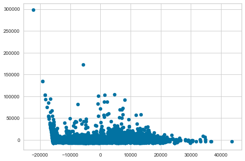

```python
ACAdata2_dr = pca.transform(ACAdata2_noid)
plt.scatter(ACAdata2_dr[:,0], ACAdata2_dr[:,1])
```

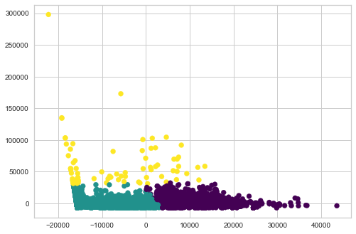

```python
from sklearn.cluster import KMeans

kmeans = KMeans(n_clusters=3)
kmeans.fit(ACAdata2_dr)
cluster_kmeans = kmeans.predict(ACAdata2_dr)

plt.scatter(ACAdata2_dr[:, 0], ACAdata2_dr[:, 1], c=cluster_kmeans, cmap='viridis')
```

## clustering

```python
import matplotlib.pyplot as plt
import numpy as np
import pandas as pd
```

```python
from yellowbrick.cluster import silhouette_visualizer
from sklearn.metrics import silhouette_score
```

After trying the "cluster=1,2,3,4", we decided to choose the three centers. Clustering in three centers seems more reasonable, even though the cluster 2 dose not look good. However, the cluster 2 in two and four centers also looks like in 3 centers, thus we choose in three centers. In three centers, the silhouette coefficient has the largest value which is 0.50.

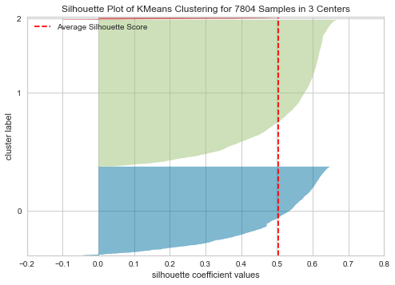

```
Silhouetter Score: 0.5027060872621795
```

```python
ACAdata2kmeans3 = KMeans(n_clusters=3)
ACAdata2kmeans3.fit(ACAdata2_noid)
cluster_ACAdata23 = ACAdata2kmeans3.predict(ACAdata2_noid)
silhouette_visualizer(ACAdata2kmeans3, ACAdata2_noid, colors='yellowbrick')
silhouetteScore3 = silhouette_score(ACAdata2_noid, cluster_ACAdata23, metric='euclidean')
print('Silhouetter Score:', silhouetteScore3)
```

## Add cluster column

```python
ACAdata23cluster = ACAdata2_noid.copy(deep=True)

ACAdata23cluster['cluster'] = cluster_ACAdata23

ACAdata23cluster
```

[output not shown]

7804 rows × 18 columns

```python
ACAdata2merge= pd.merge(ACAdata2, ACAdata23cluster)
ACAdata2merge
```

[output not shown]

15298 rows × 19 columns

## mask data by classifying cluster in 0,1,2

```python
ACAdata2mask=(ACAdata2merge['cluster']==0)
ACAdata2merge[ACAdata2mask]
```

|  | UNITID | PCIP13 | CIP13BACHL | ADM_RATE_ALL | RET_FT4 | RET_PT4 | RET_FTL4 | RET_PTL4 | C150_4 | C200_4 | C200_L4 | C150_4_POOLED | CDR3 | PELL_RPY_3YR_RT | GRAD_DEBT_MDN | WDRAW_DEBT_MDN | INEXPFTE | AVGFACSAL | cluster |
| --- | --- | --- | --- | --- | --- | --- | --- | --- | --- | --- | --- | --- | --- | --- | --- | --- | --- | --- | --- |
| 0 | 100654 | 0.1490 | 2.0 | 0.8989 | 0.6314 | 0.5000 | 0.0 | 0.0 | 0.2914 | 0.3520 | 0.0 | 0.308718 | 0.163 | 0.443586698 | 33611.5 | 14250 | 7459.0 | 7079.0 | 0 |
| 1 | 100663 | 0.0862 | 2.0 | 0.8673 | 0.8016 | 0.5000 | 0.0 | 0.0 | 0.5377 | 0.4881 | 0.0 | 0.508550 | 0.080 | 0.732297853 | 23117 | 11886 | 17208.0 | 10170.0 | 0 |
| 2 | 100690 | 0.0000 | 0.0 | 0.0000 | 0.3750 | 0.3333 | 0.0 | 0.0 | 0.6667 | 0.3333 | 0.0 | 0.285738 | 0.089 | 0.0 | 26995 | 9500 | 5123.0 | 3849.0 | 0 |
| 3 | 100706 | 0.0173 | 2.0 | 0.8062 | 0.8098 | 0.4444 | 0.0 | 0.0 | 0.4835 | 0.5048 | 0.0 | 0.478211 | 0.077 | 0.738341969 | 24738 | 10500 | 9352.0 | 9341.0 | 0 |
| 4 | 100724 | 0.2150 | 2.0 | 0.5125 | 0.6219 | 0.3023 | 0.0 | 0.0 | 0.2517 | 0.3013 | 0.0 | 0.257482 | 0.191 | 0.320016821 | 33452 | 12500 | 7393.0 | 6557.0 | 0 |
| ... | ... | ... | ... | ... | ... | ... | ... | ... | ... | ... | ... | ... | ... | ... | ... | ... | ... | ... | ... |
| 15226 | 43821206 | 0.0000 | 0.0 | 0.0000 | 0.0000 | 0.0000 | 0.0 | 0.0 | 0.0000 | 0.0000 | 0.0 | 0.000000 | 0.218 | 0.468199234 | 19811 | 7218 | 0.0 | 0.0 | 0 |
| 15227 | 43821206 | 0.0000 | 0.0 | 0.0000 | 0.0000 | 0.0000 | 0.0 | 0.0 | 0.0000 | 0.0000 | 0.0 | 0.000000 | 0.218 | 0.468199234 | 19811 | 7218 | 0.0 | 0.0 | 0 |
| 15228 | 43821206 | 0.0000 | 0.0 | 0.0000 | 0.0000 | 0.0000 | 0.0 | 0.0 | 0.0000 | 0.0000 | 0.0 | 0.000000 | 0.218 | 0.468199234 | 19811 | 7218 | 0.0 | 0.0 | 0 |
| 15229 | 43821206 | 0.0000 | 0.0 | 0.0000 | 0.0000 | 0.0000 | 0.0 | 0.0 | 0.0000 | 0.0000 | 0.0 | 0.000000 | 0.218 | 0.468199234 | 19811 | 7218 | 0.0 | 0.0 | 0 |
| 15284 | 45486501 | 0.0000 | 0.0 | 0.0000 | 0.0000 | 0.0000 | 0.0 | 0.0 | 0.0000 | 0.0000 | 0.0 | 0.000000 | 0.083 | 0.730337079 | 20000 | 9500 | 0.0 | 0.0 | 0 |

9389 rows × 19 columns

```python
ACAdata2mask=(ACAdata2merge['cluster']==1)
ACAdata2merge[ACAdata2mask]
```

|  | UNITID | PCIP13 | CIP13BACHL | ADM_RATE_ALL | RET_FT4 | RET_PT4 | RET_FTL4 | RET_PTL4 | C150_4 | C200_4 | C200_L4 | C150_4_POOLED | CDR3 | PELL_RPY_3YR_RT | GRAD_DEBT_MDN | WDRAW_DEBT_MDN | INEXPFTE | AVGFACSAL | cluster |
| --- | --- | --- | --- | --- | --- | --- | --- | --- | --- | --- | --- | --- | --- | --- | --- | --- | --- | --- | --- |
| 6 | 100760 | 0.0 | 0.0 | 0.0 | 0.0 | 0.0 | 0.4267 | 0.4159 | 0.0 | 0.0 | 0.2357 | 0.0 | 0.263 | 0.370833333 | 0.0 | 7500 | 5935.0 | 5805.0 | 1 |
| 11 | 101028 | 0.0 | 0.0 | 0.0 | 0.0 | 0.0 | 0.5165 | 0.3293 | 0.0 | 0.0 | 0.2491 | 0.0 | 0.149 | 0.470769231 | 7000 | 4051 | 4459.0 | 5749.0 | 1 |
| 14 | 101143 | 0.0 | 0.0 | 0.0 | 0.0 | 0.0 | 0.5411 | 0.4500 | 0.0 | 0.0 | 0.2369 | 0.0 | 0.250 | 0.456521739 | 11073 | 5999 | 5930.0 | 6257.0 | 1 |
| 15 | 101161 | 0.0 | 0.0 | 0.0 | 0.0 | 0.0 | 0.5211 | 0.3981 | 0.0 | 0.0 | 0.1542 | 0.0 | 0.162 | 0.526565465 | 9153 | 5500 | 4101.0 | 6116.0 | 1 |
| 17 | 101240 | 0.0 | 0.0 | 0.0 | 0.0 | 0.0 | 0.5589 | 0.3865 | 0.0 | 0.0 | 0.1926 | 0.0 | 0.285 | 0.0 | 0.0 | 0.0 | 5876.0 | 5950.0 | 1 |
| ... | ... | ... | ... | ... | ... | ... | ... | ... | ... | ... | ... | ... | ... | ... | ... | ... | ... | ... | ... |
| 15293 | 45775802 | 0.0 | 0.0 | 0.0 | 0.0 | 0.0 | 0.0000 | 0.0000 | 0.0 | 0.0 | 0.0000 | 0.0 | 0.461 | 0 | 16827 | 4750 | 0.0 | 0.0 | 1 |
| 15294 | 45920401 | 0.0 | 0.0 | 0.0 | 0.0 | 0.0 | 0.0000 | 0.0000 | 0.0 | 0.0 | 0.0000 | 0.0 | 0.012 | 1 | 10281 | 6118 | 0.0 | 0.0 | 1 |
| 15295 | 47647001 | 0.0 | 0.0 | 0.0 | 0.0 | 0.0 | 0.0000 | 0.0000 | 0.0 | 0.0 | 0.0000 | 0.0 | 0.000 | 0.0 | 15847 | 4750 | 0.0 | 0.0 | 1 |
| 15296 | 47691101 | 0.0 | 0.0 | 0.0 | 0.0 | 0.0 | 0.0000 | 0.0000 | 0.0 | 0.0 | 0.0000 | 0.0 | 0.000 | 0.0 | 9500 | 4750 | 0.0 | 0.0 | 1 |
| 15297 | 48154401 | 0.0 | 0.0 | 0.0 | 0.0 | 0.0 | 0.0000 | 0.0000 | 0.0 | 0.0 | 0.0000 | 0.0 | 0.000 | 0.0 | 6333 | 0.0 | 0.0 | 0.0 | 1 |

5833 rows × 19 columns

```python
ACAdata2mask=(ACAdata2merge['cluster']==2)
ACAdata2merge[ACAdata2mask]
```

|  | UNITID | PCIP13 | CIP13BACHL | ADM_RATE_ALL | RET_FT4 | RET_PT4 | RET_FTL4 | RET_PTL4 | C150_4 | C200_4 | C200_L4 | C150_4_POOLED | CDR3 | PELL_RPY_3YR_RT | GRAD_DEBT_MDN | WDRAW_DEBT_MDN | INEXPFTE | AVGFACSAL | cluster |
| --- | --- | --- | --- | --- | --- | --- | --- | --- | --- | --- | --- | --- | --- | --- | --- | --- | --- | --- | --- |
| 73 | 103778 | 0.0 | 0.0 | 0.0000 | 0.0000 | 0.00 | 0.0000 | 0.0 | 0.0000 | 0.0000 | 0.0000 | 0.000000 | 0.012 | 0.0 | 0.0 | 0.0 | 53366.0 | 10953.0 | 2 |
| 134 | 106263 | 0.0 | 0.0 | 0.0000 | 0.0000 | 0.00 | 0.0000 | 0.0 | 0.0000 | 0.0000 | 0.0000 | 0.000000 | 0.033 | 0.901734104 | 12820 | 10500 | 60962.0 | 7805.0 | 2 |
| 233 | 110404 | 0.0 | 0.0 | 0.1055 | 0.9659 | 0.00 | 0.0000 | 0.0 | 0.9307 | 0.8841 | 0.0000 | 0.925129 | 0.000 | 0.0 | 18348.5 | 0.0 | 92854.0 | 16120.0 | 2 |
| 253 | 110662 | 0.0 | 1.0 | 0.2199 | 0.9626 | 0.75 | 0.0000 | 0.0 | 0.9031 | 0.9027 | 0.0000 | 0.909258 | 0.022 | 0.904454343 | 15900 | 13244.5 | 38489.0 | 15089.0 | 2 |
| 256 | 110699 | 0.0 | 0.0 | 0.0000 | 0.0000 | 0.00 | 0.0000 | 0.0 | 0.0000 | 0.0000 | 0.0000 | 0.000000 | 0.003 | 0.0 | 0.0 | 0.0 | 100690.0 | 11593.0 | 2 |
| ... | ... | ... | ... | ... | ... | ... | ... | ... | ... | ... | ... | ... | ... | ... | ... | ... | ... | ... | ... |
| 6833 | 457989 | 0.0 | 0.0 | 0.0000 | 0.0000 | 0.00 | 0.5278 | 0.0 | 0.0000 | 0.0000 | 0.8889 | 0.000000 | 0.000 | 0.0 | 0.0 | 0.0 | 62818.0 | 0.0 | 2 |
| 6846 | 458122 | 0.0 | 0.0 | 0.0000 | 0.0000 | 0.00 | 0.0000 | 0.0 | 0.0000 | 0.0000 | 0.0000 | 0.000000 | 0.142 | 0.0 | 0.0 | 0.0 | 111294.0 | 0.0 | 2 |
| 7092 | 461333 | 0.0 | 0.0 | 0.0000 | 0.0000 | 0.00 | 0.0000 | 0.0 | 0.0000 | 0.0000 | 0.0000 | 0.000000 | 0.000 | 0.0 | 0.0 | 0.0 | 142817.0 | 0.0 | 2 |
| 7496 | 481030 | 0.0 | 0.0 | 0.0000 | 0.0000 | 0.00 | 0.0000 | 0.0 | 0.0000 | 0.0000 | 0.0000 | 0.000000 | 0.000 | 0.0 | 0.0 | 0.0 | 38786.0 | 0.0 | 2 |
| 7546 | 481571 | 0.0 | 0.0 | 0.0000 | 0.0000 | 0.00 | 0.0000 | 0.0 | 0.0000 | 0.0000 | 0.0000 | 0.000000 | 0.000 | 0.0 | 0.0 | 0.0 | 43841.0 | 0.0 | 2 |

76 rows × 19 columns

Based on the observation of explained variance, we know that the first two components explained the most variance.In the first two principal component outputs, the last four variables are substantially different from other variables which illustrate their significance.The four variables are GRAD_DEBT_MDN (students borrower of federal loans who complete), WDRAW_DEBT_MDN (students who withdrew without completing ), INEXPFTE (Instructional expenditures per FTE student), and AVGFACSAL (the average faculty salary).